# Dimensionality Reduction

## 11/2/2023

print view

notebook

```python
%%html
<script src="https://bits.csb.pitt.edu/preamble.js"></script>
```

## Recall

```
(4381, 23)
```

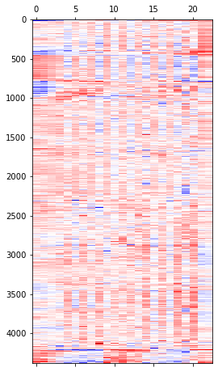

```python
from matplotlib.pylab import cm
import numpy as np
import scipy.cluster.hierarchy as hclust
import matplotlib.pyplot as plt
data = np.genfromtxt('Spellman.csv',skip_header=1,delimiter=',')[:,1:]
Z = hclust.linkage(data,method='complete')
leaves = hclust.leaves_list(Z)
ordered = data[leaves]
print(data.shape)
plt.matshow(ordered,aspect=0.01,cmap=cm.seismic);
```

```python
%%html
<div id="howdim1" style="width: 500px"></div>
<script>
    var divid = '#howdim1';
	jQuery(divid).asker({
	    id: divid,
	    question: "What is the dimensionality of this data?",
		answers: ['1','2','23','4381','None of the above'],
        server: "https://bits.csb.pitt.edu/asker.js/example/asker.cgi",
		charter: chartmaker})

$(".jp-InputArea .o:contains(html)").closest('.jp-InputArea').hide();


</script>
```

# Dimenionality Reduction

$$f(\mathbb{R}^N) \rightarrow \mathbb{R}^M, M < N$$

Usually used for visualization so reduce to 2 or 3 dimensions.

Goal is for distances in $\mathbb{R}^M$ to be representative of distances in $\mathbb{R}^N$

# PCA

Recall: principal component analysis finds an orthogonal basis that best represents the variance in the data.

[figure not shown]

```python
from sklearn.decomposition import PCA
```

```python
model = PCA(n_components=2) #specify number of components
pcaresult = model.fit_transform(data)
```

```python
model.explained_variance_ratio_
```

```
array([0.29005293, 0.15421722])
```

```python
pcaresult
```

```
array([[ 0.53743596,  0.04236283],
       [-0.52117275,  0.23262807],
       [-0.92718811, -0.02687601],
       ...,
       [ 2.22481438, -0.63181596],
       [-1.90513202,  0.62147871],
       [-1.52881942,  1.02728409]])
```

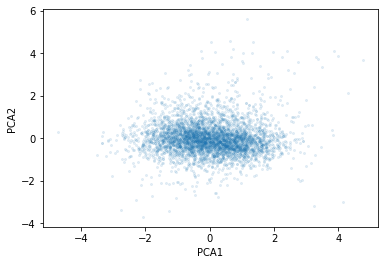

```python
plt.scatter(pcaresult[:,0],pcaresult[:,1],s=4,alpha=.1)
plt.xlabel('PCA1'); plt.ylabel('PCA2');
```

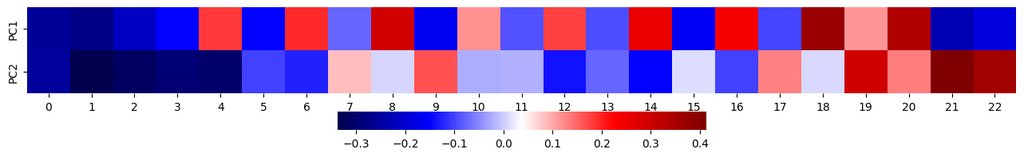

```python
import seaborn as sns
plt.figure(figsize=(16,2))
sns.heatmap(model.components_,cmap=cm.seismic,yticklabels=['PC1','PC2'],
            square=True, cbar_kws={"orientation": "horizontal"});
```

## PCA 3D

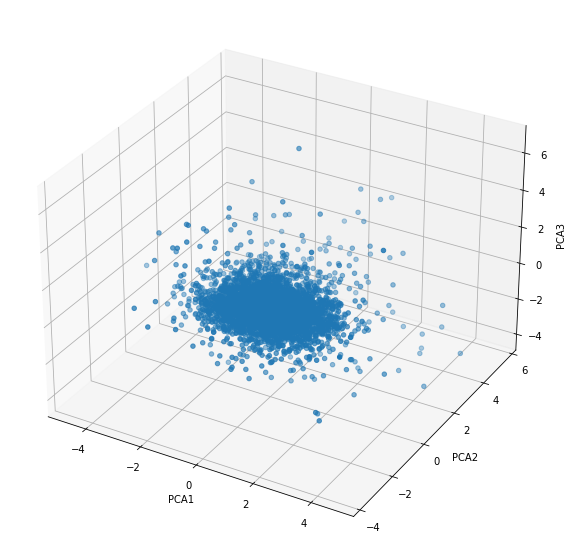

```python
model = PCA(n_components=3) #specify number of components
pcaresult = model.fit_transform(data)
fig = plt.figure(figsize=(10,10))
ax = plt.axes(projection='3d')
ax.scatter3D(pcaresult[:,0], pcaresult[:,1], pcaresult[:,2])
ax.set_xlabel('PCA1');
ax.set_ylabel('PCA2');
ax.set_zlabel('PCA3',rotation = 90);
plt.show()
```

## PCA and eigenvalues

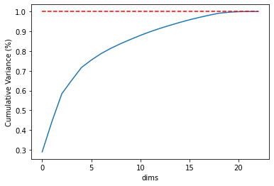

```
[2.90052934e-01 1.54217221e-01 1.39866645e-01 6.76539137e-02
 6.49586808e-02 3.77328297e-02 3.26836497e-02 2.70684145e-02
 2.34322798e-02 2.13408130e-02 2.04023716e-02 1.85849075e-02
 1.68616642e-02 1.52833017e-02 1.45935876e-02 1.34866007e-02
 1.20511650e-02 1.10991974e-02 1.01045958e-02 5.04858699e-03
 2.60581479e-03 8.70825861e-04 2.00666119e-17]
0.9999999999999998
```

```python
model = PCA(n_components=data.shape[1]) #specify number of components
pcaresult = model.fit_transform(data)
plt.plot(np.cumsum(model.explained_variance_ratio_))
plt.plot(np.repeat(1,model.explained_variance_ratio_.shape),'r--')
plt.xlabel('dims'); plt.ylabel('Cumulative Variance (%)');
plt.show()
print(model.explained_variance_ratio_)
print(np.sum(model.explained_variance_ratio_))
```

## PCA and scaling

```python
from sklearn.datasets import load_breast_cancer

bc = load_breast_cancer()
bc_data = bc['data']
bc_outcome = bc['target']

model = PCA(n_components=2)
pcaresult = model.fit_transform(bc_data);

#scaled data
from sklearn.preprocessing import StandardScaler
scaler = StandardScaler()
bc_data_scaled = scaler.fit_transform(bc_data)
model_s = PCA(n_components=2)
pcaresult_s = model_s.fit_transform(bc_data_scaled)
```

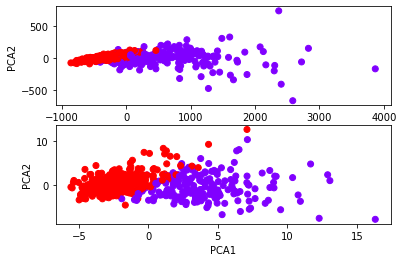

```python
fig, (ax1,ax2) = plt.subplots(2)
ax1.scatter(pcaresult[:,0],pcaresult[:,1],c=bc_outcome,cmap=cm.rainbow)
ax1.set_xlabel('PCA1'); ax1.set_ylabel('PCA2');
ax2.scatter(pcaresult_s[:,0],pcaresult_s[:,1],c=bc_outcome,cmap=cm.rainbow)
ax2.set_xlabel('PCA1'); ax2.set_ylabel('PCA2');
plt.show()
```

# Swiss roll

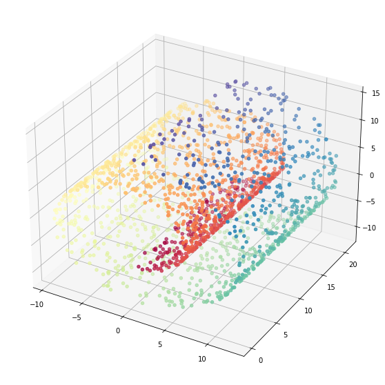

```python
import sklearn.datasets
X,color=sklearn.datasets.make_swiss_roll(n_samples=2000)
fig = plt.figure(figsize=(10,10))
ax = plt.axes(projection='3d')
ax.scatter(X[:, 0], X[:, 1], X[:, 2], c=color, cmap=cm.Spectral);
```

```python
%%html
<div id="howpca" style="width: 500px"></div>
<script>

    var divid = '#howpca';
	jQuery(divid).asker({
	    id: divid,
	    question: "What will the PCA projection to 2D of this data look like?",
		answers: ['Gaussian','Gradient','Spiral','Messy','Square'],
        server: "https://bits.csb.pitt.edu/asker.js/example/asker.cgi",
		charter: chartmaker})

$(".jp-InputArea .o:contains(html)").closest('.jp-InputArea').hide();


</script>
```

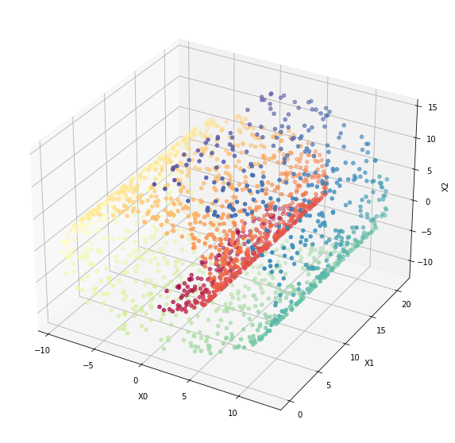

```python
from sklearn.preprocessing import StandardScaler
scaler = StandardScaler()
X_scaled = scaler.fit_transform(X)
fig = plt.figure(figsize=(10,10))
ax = plt.axes(projection='3d')
ax.scatter(X[:, 0], X[:, 1], X[:, 2], c=color, cmap=plt.cm.Spectral);
ax.set_xlabel('X0');
ax.set_ylabel('X1');
ax.set_zlabel('X2',rotation = 90);
plt.show()
```

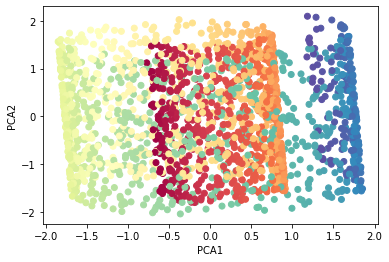

```
[0.35948427 0.33533203]
```

```python
model = PCA(n_components=2) #specify number of components
pcaresult = model.fit_transform(X_scaled)
plt.scatter(pcaresult[:,0],pcaresult[:,1],c=color,cmap=plt.cm.Spectral)
plt.xlabel('PCA1'); plt.ylabel('PCA2');
plt.show()
print(model.explained_variance_ratio_)
```

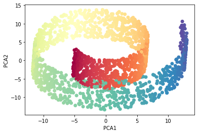

```
[0.38553847 0.31766983]
```

```python
model = PCA(n_components=2) #specify number of components
pcaresult = model.fit_transform(X)
plt.scatter(pcaresult[:,0],pcaresult[:,1],c=color,cmap=plt.cm.Spectral)
plt.xlabel('PCA1'); plt.ylabel('PCA2');
plt.show()
print(model.explained_variance_ratio_)
```

[figure not shown]

```python
plt.scatter(color,X[:,1],c=color,cmap=plt.cm.Spectral);
```

# UMAP: Uniform Manifold Approximation & Projection

https://umap-learn.readthedocs.io/en/latest/index.html

Idea: Prioritize respecting **local** distances in embedding space.

[figure not shown]

# UMAP: Uniform Manifold Approximation & Projection

UMAP constructs a $k$-nearest neighbors graph of the data. It uses an approximate **stochastic** algorithm to do this quickly.

[figure not shown]

# UMAP: Uniform Manifold Approximation & Projection

Optimizes position of data points in low dimensional space to balance attraction of locally adjacent points and repulsion of unconnected, distance points.

$$\mathrm{minimize}\sum_{e\in E} \color{blue}{ w_h(e) \log\left(\frac{w_h(e)}{w_l(e)}\right)} + \color{darkred}{(1 - w_h(e)) \log\left(\frac{1 - w_h(e)}{1 - w_l(e)}\right)}$$

$w_h(e)$ weight of edge in **high** dimensional space (larger weight = smaller distance)

$w_l(e)$ weight of edge in **low** dimensional space (larger weight = smaller distance)

This optimization is done using **stochastic gradient descent** starting at a deterministically constructed initial embedding.

# UMAP: Uniform Manifold Approximation & Projection

The `umap` package is installed with `pip3 umap-learn`

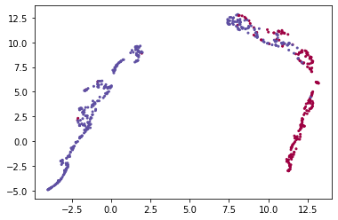

```python
import umap
model = umap.UMAP()
result = model.fit_transform(bc_data)
plt.scatter(result[:,0],result[:,1],s=4,c=bc_outcome,cmap=cm.Spectral);
```

# UMAP Parameters

- `n_neighbors` (15): Number of nearest neighbors to consider. Increase to respect global structure more.
- `min_dist` (0.1): Minimum distance between points in reduced space. Decrease to have more tightly clustered points.
- `metric` ("euclidean"): How distance is computed. Can provide user-supplied functions in addition to standard metrics

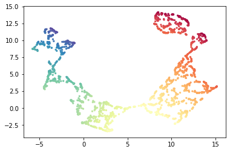

```python
model = umap.UMAP(); result = model.fit_transform(X)
plt.scatter(result[:,0],result[:,1],s=5,c=color,cmap=plt.cm.Spectral);
```

## n_neighbors

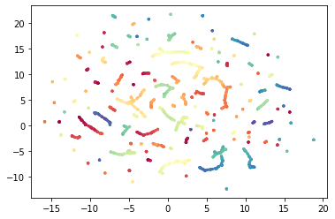

```python
model = umap.UMAP(n_neighbors=3); result = model.fit_transform(X)
plt.scatter(result[:,0],result[:,1],s=5,c=color,cmap=plt.cm.Spectral);
```

## n_neighbors

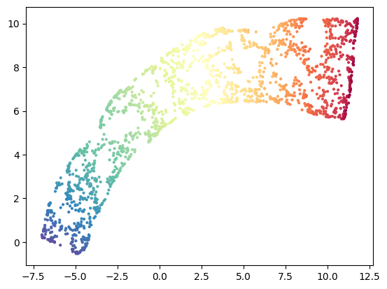

```python
model = umap.UMAP(n_neighbors=100); result = model.fit_transform(X)
plt.scatter(result[:,0],result[:,1],s=4,c=color,cmap=plt.cm.Spectral);
```

## min_dist

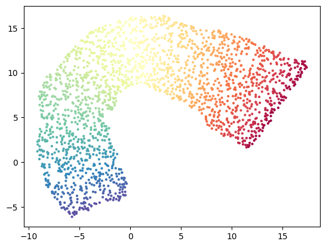

```python
model = umap.UMAP(n_neighbors=100,min_dist=1); result = model.fit_transform(X)
plt.scatter(result[:,0],result[:,1],s=4,c=color,cmap=plt.cm.Spectral);
```

## metric

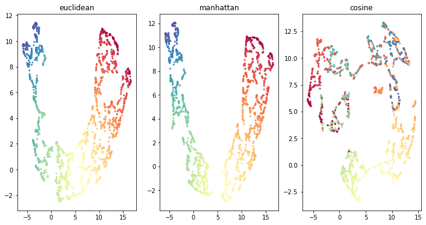

```python
fig,axes = plt.subplots(ncols=3,figsize=(12,6))
model = umap.UMAP(metric='euclidean')
result = model.fit_transform(X)
axes[0].scatter(result[:,0],result[:,1],s=4,c=color,cmap=plt.cm.Spectral); axes[0].set_title('euclidean')
model = umap.UMAP(metric='manhattan')
result = model.fit_transform(X)
axes[1].scatter(result[:,0],result[:,1],s=4,c=color,cmap=plt.cm.Spectral); axes[1].set_title('manhattan');
model = umap.UMAP(metric='cosine')
result = model.fit_transform(X)
axes[2].scatter(result[:,0],result[:,1],s=4,c=color,cmap=plt.cm.Spectral); axes[2].set_title('cosine');
```

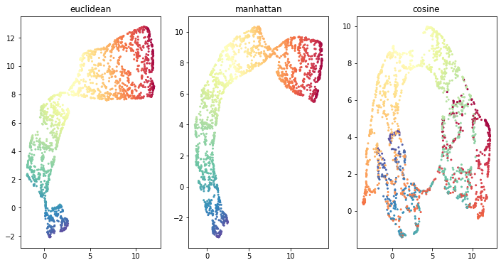

```python
fig,axes = plt.subplots(ncols=3,figsize=(12,6))
model = umap.UMAP(metric='euclidean',n_neighbors=100)
result = model.fit_transform(X)
axes[0].scatter(result[:,0],result[:,1],s=4,c=color,cmap=plt.cm.Spectral); axes[0].set_title('euclidean')
model = umap.UMAP(metric='manhattan', n_neighbors=100)
result = model.fit_transform(X)
axes[1].scatter(result[:,0],result[:,1],s=4,c=color,cmap=plt.cm.Spectral); axes[1].set_title('manhattan');
model = umap.UMAP(metric='cosine', n_neighbors=100)
result = model.fit_transform(X)
axes[2].scatter(result[:,0],result[:,1],s=4,c=color,cmap=plt.cm.Spectral); axes[2].set_title('cosine');
```

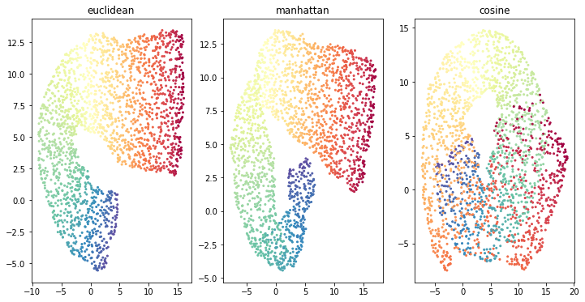

```python
fig,axes = plt.subplots(ncols=3,figsize=(12,6))
model = umap.UMAP(metric='euclidean',n_neighbors=100,min_dist=1)
result = model.fit_transform(X)
axes[0].scatter(result[:,0],result[:,1],s=4,c=color,cmap=plt.cm.Spectral); axes[0].set_title('euclidean')
model = umap.UMAP(metric='manhattan', n_neighbors=100,min_dist=1)
result = model.fit_transform(X)
axes[1].scatter(result[:,0],result[:,1],s=4,c=color,cmap=plt.cm.Spectral); axes[1].set_title('manhattan');
model = umap.UMAP(metric='cosine', n_neighbors=100,min_dist=1)
result = model.fit_transform(X)
axes[2].scatter(result[:,0],result[:,1],s=4,c=color,cmap=plt.cm.Spectral); axes[2].set_title('cosine');
```

# UMAP vs. t-SNE

t-SNE (t-distributed stochastic neighbor embedding) is an older method that also uses a notion of preserving local distances

- doesn't use nearest neighbor graph (slower)
- different cost function for optimizing embedding
- more sensitive to parameters
- default to stochastic initialization of optimization

# Project

Download the below heavily downsampled RNASeq data and visualize it in 2D both with PCA and UMAP.

Color the points by the labels.

```python
!wget  http://mscbio2025.net/files/mouse_data/X.csv.gz
!wget  http://mscbio2025.net/files/mouse_data/obs.csv
```

[output not shown]

```python
data = np.genfromtxt('X.csv.gz',delimiter=',')
labels = np.genfromtxt('obs.csv',delimiter=',',dtype=str,skip_header=1)[:,1]
```

```python
#convert labels (strings) to numbers so they can be used as colors in matplotlib
from sklearn import preprocessing
colors = preprocessing.LabelEncoder().fit_transform(labels)
```

```python
data.shape
```

```
(1196, 4286)
```

```python
labels.shape
```

```
(1196,)
```

```python
#can use umap's plotting function and provide labels as strings
import umap.plot
```